# Blunt-nosed Leopard Lizard Data Analysis: Water Physiology Nuances

## Female Subset

To look at reproductive effort ~ water balance, I will make another subset for only the females we collected gravidity/egg data on:

```r
dat_repro_females <- dat %>%
  dplyr::filter(sex_M_F == "Female") %>%
  dplyr::filter(complete.cases(gravid_Y_N)) %>%
  group_by(individual_ID) %>%
  mutate(n = n(),
         n = factor(n))
summary(dat_repro_females)
```

```
##  capture_date_time                capture_date        radio_collar_serial
##  Min.   :2021-04-23 04:19:00.0   Min.   :2021-04-23   Length:28
##  1st Qu.:2021-04-23 08:30:00.0   1st Qu.:2021-04-23   Class :character
##  Median :2021-04-24 04:11:00.0   Median :2021-04-24   Mode  :character
##  Mean   :2021-04-28 09:34:38.4   Mean   :2021-04-29
##  3rd Qu.:2021-05-08 01:54:00.0   3rd Qu.:2021-05-08
##  Max.   :2021-05-08 07:19:00.0   Max.   :2021-05-08
##  NA's   :3
##   PIT_tag_ID        individual_ID   sex_M_F       mass_g          SVL_mm
##  Length:28          F-01   : 2    Female:28   Min.   :26.00   Min.   : 85.0
##  Class :character   F-03   : 2    Male  : 0   1st Qu.:33.52   1st Qu.: 95.0
##  Mode  :character   F-05   : 2                Median :38.00   Median :100.0
##                     F-06   : 2                Mean   :39.79   Mean   :101.1
##                     F-11   : 2                3rd Qu.:44.50   3rd Qu.:108.0
##                     F-12   : 2                Max.   :58.80   Max.   :114.0
##                     (Other):16
##         tmt     tmt_mass_change_g capture_to_msmt  hematocrit_percent
##  Water Tmt:15   Min.   :-3.0000   Min.   :  25.0   Min.   :18.00
##  Sham Tmt :13   1st Qu.:-1.0000   1st Qu.:  49.0   1st Qu.:26.75
##  No Tmt   : 0   Median :-0.1000   Median : 118.0   Median :32.00
##                 Mean   :-0.4519   Mean   : 238.8   Mean   :32.14
##                 3rd Qu.: 0.0000   3rd Qu.: 163.0   3rd Qu.:37.00
##                 Max.   : 1.9000   Max.   :1665.0   Max.   :44.00
##                 NA's   :1         NA's   :3
##  cloacal_temp_C    CEWL_g_m2h      msmt_temp_C    msmt_RH_percent
##  Min.   :28.00   Min.   : 1.493   Min.   :23.13   Min.   :12.20
##  1st Qu.:33.00   1st Qu.: 9.171   1st Qu.:30.36   1st Qu.:14.38
##  Median :34.00   Median :10.239   Median :31.40   Median :15.55
##  Mean   :33.46   Mean   :11.423   Mean   :30.70   Mean   :16.98
##  3rd Qu.:35.00   3rd Qu.:13.613   3rd Qu.:31.93   3rd Qu.:19.05
##  Max.   :36.00   Max.   :21.673   Max.   :33.55   Max.   :28.17
##
##     e_s_kPa       msmt_VPD_kPa   osmolality_mmol_kg_mean   month    week
##  Min.   :2.830   Min.   :2.033   Min.   :309.3           April:17   1 :17
##  1st Qu.:4.331   1st Qu.:3.600   1st Qu.:337.8           May  :11   3 :11
##  Median :4.595   Median :3.863   Median :346.6           July : 0   12: 0
##  Mean   :4.444   Mean   :3.705   Mean   :352.6
##  3rd Qu.:4.736   3rd Qu.:4.050   3rd Qu.:369.2
##  Max.   :5.188   Max.   :4.319   Max.   :402.0
##
```

[output cut: 17 more lines]

```
##  Min.   :1.00   Min.   :27.04   April Female:17   Apr 23-25:17
##  1st Qu.:2.00   1st Qu.:32.45   April Male  : 0   May 7-9  :11
##  Median :2.00   Median :34.89   May Female  :11   Jul 14   : 0
##  Mean   :2.75   Mean   :35.82   May Male    : 0
##  3rd Qu.:3.25   3rd Qu.:40.19   July Female : 0
##  Max.   :5.00   Max.   :45.63   July Male   : 0
##  NA's   :12
##  percent_water_mass_change n
##  Min.   :-6.834            2:18
##  1st Qu.:-3.046            1:10
##  Median :-0.250
##  Mean   :-1.171
##  3rd Qu.: 0.000
##  Max.   : 7.037
##  NA's   :1
```

It’s good to note that I measured reproductive effort at **two time points** for 9 females, and only at one time point for 10 females.

Check whether the single-measurement females are all from the first weekend or not:

```r
table(dat_repro_females$week, dat_repro_females$n)
```

```
##
##      2 1
##   1  9 8
##   3  9 2
##   12 0 0
```

```r
dat_repro_females %>%
  dplyr::filter(n == 1) %>%
  summary() # 4 g, 6 ng
```

```
##  capture_date_time              capture_date        radio_collar_serial
##  Min.   :2021-04-23 04:19:00   Min.   :2021-04-23   Length:10
##  1st Qu.:2021-04-24 02:57:00   1st Qu.:2021-04-24   Class :character
##  Median :2021-04-24 04:10:00   Median :2021-04-24   Mode  :character
##  Mean   :2021-04-25 13:16:20   Mean   :2021-04-26
##  3rd Qu.:2021-04-24 05:56:00   3rd Qu.:2021-04-24
##  Max.   :2021-05-08 07:19:00   Max.   :2021-05-08
##  NA's   :1
##   PIT_tag_ID        individual_ID   sex_M_F       mass_g          SVL_mm
##  Length:10          F-02   :1     Female:10   Min.   :26.00   Min.   : 85.00
##  Class :character   F-04   :1     Male  : 0   1st Qu.:32.00   1st Qu.: 96.25
##  Mode  :character   F-07   :1                 Median :37.50   Median :103.50
##                     F-08   :1                 Mean   :36.30   Mean   :101.80
##                     F-08a  :1                 3rd Qu.:41.75   3rd Qu.:110.25
##                     F-09   :1                 Max.   :47.00   Max.   :114.00
##                     (Other):4
##         tmt    tmt_mass_change_g capture_to_msmt  hematocrit_percent
##  Water Tmt:7   Min.   :-1.00     Min.   :  35.0   Min.   :18.00
##  Sham Tmt :3   1st Qu.:-1.00     1st Qu.:  49.0   1st Qu.:25.00
##  No Tmt   :0   Median :-0.50     Median :  91.0   Median :26.00
##                Mean   :-0.21     Mean   : 261.7   Mean   :29.20
##                3rd Qu.: 0.00     3rd Qu.: 132.0   3rd Qu.:35.75
##                Max.   : 1.90     Max.   :1665.0   Max.   :41.00
##                                  NA's   :1
##  cloacal_temp_C    CEWL_g_m2h      msmt_temp_C    msmt_RH_percent
##  Min.   :28.00   Min.   : 8.457   Min.   :25.03   Min.   :14.12
##  1st Qu.:32.25   1st Qu.: 9.554   1st Qu.:29.50   1st Qu.:15.05
##  Median :33.50   Median :10.159   Median :30.96   Median :16.91
##  Mean   :33.00   Mean   :11.986   Mean   :30.54   Mean   :18.24
##  3rd Qu.:34.00   3rd Qu.:14.551   3rd Qu.:32.12   3rd Qu.:20.05
##  Max.   :35.00   Max.   :18.743   Max.   :33.55   Max.   :26.03
##
##     e_s_kPa       msmt_VPD_kPa   osmolality_mmol_kg_mean   month   week
##  Min.   :3.172   Min.   :2.346   Min.   :309.3           April:8   1 :8
##  1st Qu.:4.124   1st Qu.:3.341   1st Qu.:330.6           May  :2   3 :2
##  Median :4.482   Median :3.776   Median :357.3           July :0   12:0
##  Mean   :4.410   Mean   :3.623   Mean   :355.6
##  3rd Qu.:4.786   3rd Qu.:4.014   3rd Qu.:378.2
##  Max.   :5.188   Max.   :4.319   Max.   :402.0
##
```

[output cut: 17 more lines]

```
##  Min.   :2.00   Min.   :27.04   April Female:8   Apr 23-25:8
##  1st Qu.:2.00   1st Qu.:30.81   April Male  :0   May 7-9  :2
##  Median :2.00   Median :32.93   May Female  :2   Jul 14   :0
##  Mean   :2.75   Mean   :32.21   May Male    :0
##  3rd Qu.:2.75   3rd Qu.:33.44   July Female :0
##  Max.   :5.00   Max.   :37.68   July Male   :0
##  NA's   :6
##  percent_water_mass_change n
##  Min.   :-3.8462           2: 0
##  1st Qu.:-2.6849           1:10
##  Median :-1.1628
##  Mean   :-0.5466
##  3rd Qu.: 0.0000
##  Max.   : 7.0370
##
```

```r
dat_repro_females %>%
  dplyr::filter(n == 2) %>%
  dplyr::filter(week == 3) %>%
  summary() # 8 g, 1 ng
```

```
##  capture_date_time                 capture_date        radio_collar_serial
##  Min.   :2021-05-08 01:40:00.00   Min.   :2021-05-08   Length:9
##  1st Qu.:2021-05-08 02:09:00.00   1st Qu.:2021-05-08   Class :character
##  Median :2021-05-08 02:58:00.00   Median :2021-05-08   Mode  :character
##  Mean   :2021-05-08 03:06:42.85   Mean   :2021-05-08
##  3rd Qu.:2021-05-08 03:42:00.00   3rd Qu.:2021-05-08
##  Max.   :2021-05-08 05:27:00.00   Max.   :2021-05-08
##  NA's   :2
##   PIT_tag_ID        individual_ID   sex_M_F      mass_g          SVL_mm
##  Length:9           F-01   :1     Female:9   Min.   :33.70   Min.   : 90.00
##  Class :character   F-03   :1     Male  :0   1st Qu.:35.60   1st Qu.: 95.00
##  Mode  :character   F-05   :1                Median :43.90   Median : 98.00
##                     F-06   :1                Mean   :44.02   Mean   : 99.56
##                     F-11   :1                3rd Qu.:52.70   3rd Qu.:105.00
##                     F-12   :1                Max.   :58.80   Max.   :110.00
##                     (Other):3
##         tmt    tmt_mass_change_g capture_to_msmt hematocrit_percent
##  Water Tmt:4   Min.   :-3.0      Min.   : 59.0   Min.   :31.00
##  Sham Tmt :5   1st Qu.:-1.5      1st Qu.:158.5   1st Qu.:32.00
##  No Tmt   :0   Median :-1.0      Median :244.0   Median :37.00
##                Mean   :-1.0      Mean   :201.7   Mean   :37.33
##                3rd Qu.: 0.0      3rd Qu.:259.5   3rd Qu.:43.00
##                Max.   : 1.0      Max.   :273.0   Max.   :44.00
##                NA's   :1         NA's   :2
##  cloacal_temp_C    CEWL_g_m2h      msmt_temp_C    msmt_RH_percent
##  Min.   :33.00   Min.   : 8.318   Min.   :30.40   Min.   :13.12
##  1st Qu.:34.00   1st Qu.: 9.318   1st Qu.:30.86   1st Qu.:14.44
##  Median :35.00   Median :10.286   Median :31.45   Median :14.70
##  Mean   :34.56   Mean   :10.915   Mean   :31.38   Mean   :14.78
##  3rd Qu.:35.00   3rd Qu.:12.213   3rd Qu.:31.90   3rd Qu.:15.48
##  Max.   :36.00   Max.   :14.378   Max.   :32.04   Max.   :15.84
##
##     e_s_kPa       msmt_VPD_kPa   osmolality_mmol_kg_mean   month   week
##  Min.   :4.340   Min.   :3.685   Min.   :337.3           April:0   1 :0
##  1st Qu.:4.456   1st Qu.:3.813   1st Qu.:340.5           May  :9   3 :9
##  Median :4.608   Median :3.939   Median :361.0           July :0   12:0
##  Mean   :4.591   Mean   :3.913   Mean   :357.0
##  3rd Qu.:4.728   3rd Qu.:4.028   3rd Qu.:369.0
##  Max.   :4.765   Max.   :4.112   Max.   :379.5
##
```

[output cut: 17 more lines]

```
##  Min.   :1.000   Min.   :34.49   April Female:0   Apr 23-25:0
##  1st Qu.:2.000   1st Qu.:36.44   April Male  :0   May 7-9  :9
##  Median :3.000   Median :41.85   May Female  :9   Jul 14   :0
##  Mean   :3.125   Mean   :40.73   May Male    :0
##  3rd Qu.:4.250   3rd Qu.:43.87   July Female :0
##  Max.   :5.000   Max.   :45.63   July Male   :0
##  NA's   :1
##  percent_water_mass_change n
##  Min.   :-6.834            2:9
##  1st Qu.:-3.649            1:0
##  Median :-2.468
##  Mean   :-2.203
##  3rd Qu.: 0.000
##  Max.   : 2.809
##  NA's   :1
```

```r
table(dat_repro_females$gravid_Y_N, dat_repro_females$n)
```

```
##
##               2  1
##   Not Gravid  6  6
##   Gravid     12  4
```

For the females who were only measured once, 8 of them are from the first weekend and 2 of them are from the third weekend.

Also save a subset of the females that were measured twice:

```r
dat_repeat_females <- dat_repro_females %>%
  dplyr::filter(n == 2)
```

# Does SVL change over time?

I want to know whether SVL changed over time for the individuals who had more than one measurement taken.

```r
# model
summary(lmerTest::lmer(data = dat_repeats,
                   SVL_mm ~ week_num + (1|individual_ID)))
```

```
## Linear mixed model fit by REML. t-tests use Satterthwaite's method [
## lmerModLmerTest]
## Formula: SVL_mm ~ week_num + (1 | individual_ID)
##    Data: dat_repeats
##
## REML criterion at convergence: 495.2
##
## Scaled residuals:
##      Min       1Q   Median       3Q      Max
## -1.46209 -0.38905 -0.04905  0.51484  2.46481
##
## Random effects:
##  Groups        Name        Variance Std.Dev.
##  individual_ID (Intercept) 55.65    7.460
##  Residual                  19.96    4.467
## Number of obs: 74, groups:  individual_ID, 34
##
## Fixed effects:
##             Estimate Std. Error       df t value Pr(>|t|)
## (Intercept) 100.5373     1.4817  42.0626  67.852   <2e-16 ***
## week_num      0.1016     0.1442  42.5756   0.705    0.485
## ---
## Signif. codes:  0 '***' 0.001 '**' 0.01 '*' 0.05 '.' 0.1 ' ' 1
##
## Correlation of Fixed Effects:
##          (Intr)
## week_num -0.359
```

There is no meaningful change in SVL for the individuals we were able to measure, so I could use either mass or body condition to estimate change in body size over time.

# Check CEWL Covariates

How much is CEWL impacted by the body temperature, ambient temperature, and ambient VPD at the time of CEWL measurement? I will investigate this using *all* measurements.

It’s possible that I may find a relationship between ambient temp and CEWL but not body temp and CEWL because the body temp measurements we took were unfortunately only to the nearest degree (vs tenth of a degree).

## Plot

First, make a simple plot of each to look for relationships visually.

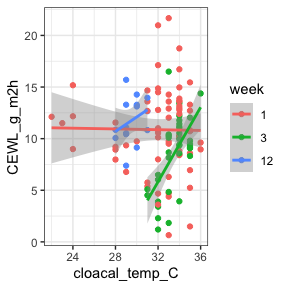

```r
ggplot(dat) +
  aes(x = cloacal_temp_C,
      y = CEWL_g_m2h,
      color = week
      #color = sex_M_F
        ) +
  geom_point() +
  geom_smooth(method = "lm") +
  theme_bw()
```

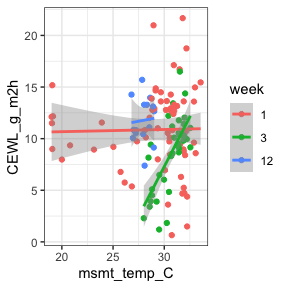

```r
ggplot(dat) +
  aes(x = msmt_temp_C,
      y = CEWL_g_m2h,
      color = week
      #color = sex_M_F
        ) +
  geom_point() +
  geom_smooth(method = "lm") +
  theme_bw()
```

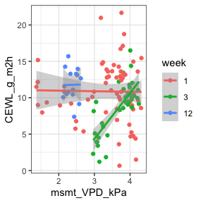

```r
ggplot(dat) +
  aes(x = msmt_VPD_kPa,
      y = CEWL_g_m2h,
      color = week
      #color = sex_M_F
        ) +
  geom_point() +
  geom_smooth(method = "lm") +
  theme_bw()
```

Across dates, CEWL had no relationship with body temp, ambient temp, or ambient VPD at the time of capture. However, when separated by date, there were relationships. CEWL had a positive relationship with body temp, ambient temp, and ambient VPD, but only for week 3 measurements. There were no relationships when separated by treatment group.

## Models

Now, check linear models of the effect of each of body temp, ambient temp, and ambient VPD with the interaction of date on CEWL.

```r
CEWL_cov_check_clotemp <- lm(data = dat,
           CEWL_g_m2h ~ cloacal_temp_C*week)
summary(CEWL_cov_check_clotemp)
```

```
##
## Call:
## lm(formula = CEWL_g_m2h ~ cloacal_temp_C * week, data = dat)
##
## Residuals:
##      Min       1Q   Median       3Q      Max
## -10.1993  -2.0150   0.1478   2.0471  10.8241
##
## Coefficients:
##                        Estimate Std. Error t value Pr(>|t|)
## (Intercept)            11.45021    4.57266   2.504 0.013718 *
## cloacal_temp_C         -0.01821    0.14195  -0.128 0.898154
## week3                 -63.35695   17.24290  -3.674 0.000367 ***
## week12                -20.29849   29.16728  -0.696 0.487912
## cloacal_temp_C:week3    1.82229    0.51531   3.536 0.000591 ***
## cloacal_temp_C:week12   0.71647    0.98516   0.727 0.468586
## ---
## Signif. codes:  0 '***' 0.001 '**' 0.01 '*' 0.05 '.' 0.1 ' ' 1
##
## Residual standard error: 3.613 on 112 degrees of freedom
##   (1 observation deleted due to missingness)
## Multiple R-squared:  0.1888, Adjusted R-squared:  0.1526
## F-statistic: 5.213 on 5 and 112 DF,  p-value: 0.0002434
```

```r
CEWL_cov_check_msmttemp <- lm(data = dat,
           CEWL_g_m2h ~ msmt_temp_C*week)
summary(CEWL_cov_check_msmttemp)
```

```
##
## Call:
## lm(formula = CEWL_g_m2h ~ msmt_temp_C * week, data = dat)
##
## Residuals:
##      Min       1Q   Median       3Q      Max
## -10.2517  -1.5583  -0.3139   2.0494  10.7491
##
## Coefficients:
##                     Estimate Std. Error t value Pr(>|t|)
## (Intercept)         10.25244    3.27104   3.134   0.0022 **
## msmt_temp_C          0.02113    0.11155   0.189   0.8501
## week3              -60.68682   14.33616  -4.233 4.74e-05 ***
## week12              -3.76401   34.56181  -0.109   0.9135
## msmt_temp_C:week3    1.90326    0.46806   4.066 8.91e-05 ***
## msmt_temp_C:week12   0.16788    1.23504   0.136   0.8921
## ---
## Signif. codes:  0 '***' 0.001 '**' 0.01 '*' 0.05 '.' 0.1 ' ' 1
##
## Residual standard error: 3.554 on 112 degrees of freedom
##   (1 observation deleted due to missingness)
## Multiple R-squared:  0.2149, Adjusted R-squared:  0.1799
## F-statistic: 6.133 on 5 and 112 DF,  p-value: 4.648e-05
```

```r
CEWL_cov_check_VPD <- lm(data = dat,
           CEWL_g_m2h ~ msmt_VPD_kPa*week)
summary(CEWL_cov_check_VPD)
```

```
##
## Call:
## lm(formula = CEWL_g_m2h ~ msmt_VPD_kPa * week, data = dat)
##
## Residuals:
##      Min       1Q   Median       3Q      Max
## -10.1892  -1.7946  -0.3724   2.0215  10.8386
##
## Coefficients:
##                      Estimate Std. Error t value Pr(>|t|)
## (Intercept)          11.13212    1.80429   6.170 1.12e-08 ***
## msmt_VPD_kPa         -0.07911    0.52156  -0.152    0.880
## week3               -25.66036    5.31654  -4.827 4.43e-06 ***
## week12                0.33315   13.99194   0.024    0.981
## msmt_VPD_kPa:week3    6.37242    1.44871   4.399 2.49e-05 ***
## msmt_VPD_kPa:week12   0.20939    5.87420   0.036    0.972
## ---
## Signif. codes:  0 '***' 0.001 '**' 0.01 '*' 0.05 '.' 0.1 ' ' 1
##
## Residual standard error: 3.504 on 112 degrees of freedom
##   (1 observation deleted due to missingness)
## Multiple R-squared:  0.2368, Adjusted R-squared:  0.2027
## F-statistic:  6.95 on 5 and 112 DF,  p-value: 1.093e-05
```

```r
# F stats
car::Anova(CEWL_cov_check_clotemp, type = "II")
```

```
## Anova Table (Type II tests)
##
## Response: CEWL_g_m2h
##                      Sum Sq  Df F value   Pr(>F)
## cloacal_temp_C        12.30   1  0.9422 0.333793
## week                 169.15   2  6.4797 0.002173 **
## cloacal_temp_C:week  167.73   2  6.4253 0.002282 **
## Residuals           1461.83 112
## ---
## Signif. codes:  0 '***' 0.001 '**' 0.01 '*' 0.05 '.' 0.1 ' ' 1
```

```r
car::Anova(CEWL_cov_check_msmttemp, type = "II")
```

```
## Anova Table (Type II tests)
##
## Response: CEWL_g_m2h
##                   Sum Sq  Df F value    Pr(>F)
## msmt_temp_C        18.24   1  1.4441 0.2320199
## week              178.22   2  7.0546 0.0013014 **
## msmt_temp_C:week  208.88   2  8.2684 0.0004474 ***
## Residuals        1414.73 112
## ---
## Signif. codes:  0 '***' 0.001 '**' 0.01 '*' 0.05 '.' 0.1 ' ' 1
```

```r
car::Anova(CEWL_cov_check_VPD, type = "II")
```

```
## Anova Table (Type II tests)
##
## Response: CEWL_g_m2h
##                    Sum Sq  Df F value    Pr(>F)
## msmt_VPD_kPa        28.80   1  2.3452 0.1284889
## week               188.86   2  7.6898 0.0007423 ***
## msmt_VPD_kPa:week  237.73   2  9.6798 0.0001325 ***
## Residuals         1375.33 112
## ---
## Signif. codes:  0 '***' 0.001 '**' 0.01 '*' 0.05 '.' 0.1 ' ' 1
```

CEWL had a positive relationship with each of body temp, ambient temp, and ambient VPD, *but only for the measurements taken in May* (week 3).

## Variance

Let’s also check the distribution/range of these covariates, because based on the figures, week 3 had a pretty small range of temperatures and VPDs.

```r
dat %>%
  group_by(week) %>%
  summarise(ctemp_range = max(cloacal_temp_C, na.rm = T) -
              min(cloacal_temp_C, na.rm = T),
            mtemp_range = max(msmt_temp_C, na.rm = T) -
              min(msmt_temp_C, na.rm = T),
            mVPD_range = max(msmt_VPD_kPa, na.rm = T) -
              min(msmt_VPD_kPa, na.rm = T))
```

```
## # A tibble: 3 × 4
##   week  ctemp_range mtemp_range mVPD_range
##   <fct>       <dbl>       <dbl>      <dbl>
## 1 1              14       14.5       2.95
## 2 3               5        4.55      1.28
## 3 12              3        2.22      0.495
```

Well… the ranges for week 3 are not small enough to be meaningless. So, we will have to keep in mind that temperature and VPD should be retained in CEWL models as a covariate.